# CYCLONE_TRACKING_ANALYSIS

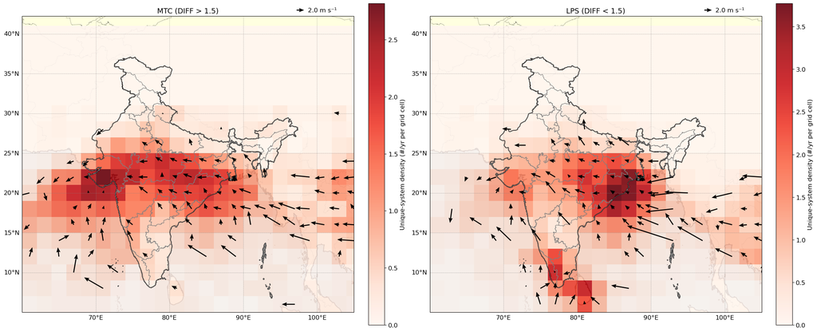

```python
import numpy as np
import xarray as xr
import matplotlib.pyplot as plt
import cartopy.crs as ccrs
import cartopy.feature as cfeature
from scipy.stats import ttest_1samp
import geopandas as gpd

# ============================================================
# USER-CONTROL PARAMETERS
# ============================================================
GRID_SIZE      = 2.0
LAT_RANGE      = (5, 40)
LON_RANGE      = (60, 105)

GENESIS_LAT_MAX = 25
TRACK_LEN_MIN   = 8
SPEED_MIN_MS    = 1
Q_RECORD_MIN    = 2.0
MIN_SAMPLES     = 10
SIG_LEVEL       = 0.1

DENSITY_MODE    = "mean"
DATA_FILE       = "/home/pradeep/Desktop/AUTOMATIC_TRACKING_GUTHUB/DATA/MID_CYCLONE_TRACKS_JUN_SEP_1998-2019_600hPa.nc"
N_YEARS         = 2019 - 1998 + 1

QUIVER_SHOW_ONLY_SIGNIFICANT = True
QUIVER_REF_MS     = 2.0
QUIVER_REF_INCH   = 0.2
QUIVER_SCALE_UNITS = "inches"
QUIVER_SCALE      = QUIVER_REF_MS / QUIVER_REF_INCH
QUIVER_WIDTH      = 0.003
QUIVER_HEADWIDTH  = 4
QUIVER_KEY_POS    = (0.85, 1.02)
QUIVER_KEY_LABELPOS = 'E'

MIN_DIFF_POINTS = 12
FONT_SIZE = 12  # Publication font size

# ============================================================
# Load dataset
# ============================================================
ds = xr.open_dataset(DATA_FILE)
track_lengths = ds["TRACK_LENGTH"].values
lat_rec = ds["LAT_RECORD"].values
lon_rec = ds["LON_RECORD"].values
q_rec   = ds["Q_RECORD"].values
diff_rec = ds["DIFF_RECORD"].values

# Define grid
lat_bins = np.arange(LAT_RANGE[0], LAT_RANGE[1] + GRID_SIZE, GRID_SIZE)
lon_bins = np.arange(LON_RANGE[0], LON_RANGE[1] + GRID_SIZE, GRID_SIZE)

# ============================================================
# Helper functions
# ============================================================
def haversine(lat1, lon1, lat2, lon2):
    R = 6371.0
    lat1, lon1, lat2, lon2 = map(np.radians, [lat1, lon1, lat2, lon2])
    dlat = lat2 - lat1
    dlon = lon2 - lon1
    a = np.sin(dlat/2)**2 + np.cos(lat1)*np.cos(lat2)*np.sin(dlon/2)**2
    return R * 2 * np.arcsin(np.sqrt(a))

def process_tracks(diff_condition, min_diff):
    H_unique = np.zeros((lat_bins.size - 1, lon_bins.size - 1), dtype=int)
    U_list = [[[] for _ in range(H_unique.shape[1])] for _ in range(H_unique.shape[0])]
    V_list = [[[] for _ in range(H_unique.shape[1])] for _ in range(H_unique.shape[0])]
    valid_ids = []
    dt = 6*3600

    for i in range(track_lengths.shape[0]):
        tl = int(track_lengths[i])
        if tl < TRACK_LEN_MIN:
            continue
        lats = lat_rec[i, :tl]
        lons = lon_rec[i, :tl]
        if not (np.isfinite(lats[0]) and np.isfinite(lons[0])):
            continue
        if lats[0] >= GENESIS_LAT_MAX:
            continue
        # Mean speed
        dist_km = np.nansum(haversine(lats[:-1], lons[:-1], lats[1:], lons[1:]))
        hours = max(tl-1,1)*6
        mean_speed_ms = (dist_km*1000)/(hours*3600)
        if mean_speed_ms < SPEED_MIN_MS:
            continue
        if np.nanmax(q_rec[i,:tl]) <= Q_RECORD_MIN:
            continue
        # DIFF_RECORD filter
        diff_vals = diff_rec[i,:tl]
        if diff_condition == 'gt' and np.sum(diff_vals > min_diff) < MIN_DIFF_POINTS:
            continue
        if diff_condition == 'lt' and np.sum(diff_vals < min_diff) < MIN_DIFF_POINTS:
            continue
        # Unique density
        li = np.digitize(lats, lat_bins)-1
        lj = np.digitize(lons, lon_bins)-1
        mask = (li >=0) & (li<H_unique.shape[0]) & (lj>=0) & (lj<H_unique.shape[1])
        visited = set(zip(li[mask], lj[mask]))
        for ii,jj in visited:
            H_unique[ii,jj] += 1
        # Stepwise velocities
        for k in range(tl-1):
            if not (np.isfinite(lats[k]) and np.isfinite(lons[k]) and np.isfinite(lats[k+1]) and np.isfinite(lons[k+1])):
                continue
            ii = np.digitize(lats[k], lat_bins)-1
            jj = np.digitize(lons[k], lon_bins)-1
            if ii<0 or ii>=H_unique.shape[0] or jj<0 or jj>=H_unique.shape[1]:
                continue
            dlat = lats[k+1]-lats[k]
            dlon = lons[k+1]-lons[k]
            mean_lat_rad = np.radians((lats[k]+lats[k+1])/2.0)
            dy_m = dlat*111e3
            dx_m = dlon*111e3*np.cos(mean_lat_rad)
            u = dx_m/dt
            v = dy_m/dt
            U_list[ii][jj].append(u)
            V_list[ii][jj].append(v)
        valid_ids.append(i)

    # Density
    if DENSITY_MODE.lower() == 'mean':
        H_plot = H_unique / N_YEARS
    else:
        H_plot = H_unique

    # Mean vectors
    U_mean = np.full_like(H_unique, np.nan, dtype=float)
    V_mean = np.full_like(H_unique, np.nan, dtype=float)
    mask_sig = np.zeros_like(H_unique, dtype=bool)

    for ii in range(H_unique.shape[0]):
        for jj in range(H_unique.shape[1]):
            u_vals = np.asarray(U_list[ii][jj], dtype=float)
            v_vals = np.asarray(V_list[ii][jj], dtype=float)
            if u_vals.size < MIN_SAMPLES:
                continue
            t_u,p_u = ttest_1samp(u_vals,0.0,nan_policy='omit')
            t_v,p_v = ttest_1samp(v_vals,0.0,nan_policy='omit')
            if QUIVER_SHOW_ONLY_SIGNIFICANT:
                if (p_u<SIG_LEVEL) or (p_v<SIG_LEVEL):
                    U_mean[ii,jj]=np.nanmean(u_vals)
                    V_mean[ii,jj]=np.nanmean(v_vals)
                    mask_sig[ii,jj]=True
            else:
                U_mean[ii,jj]=np.nanmean(u_vals)
                V_mean[ii,jj]=np.nanmean(v_vals)
                mask_sig[ii,jj]=True

    return H_plot, U_mean, V_mean, mask_sig

# ============================================================
# Prepare figure with 2 subplots
# ============================================================
fig, axes = plt.subplots(1,2,figsize=(22,9), subplot_kw={'projection': ccrs.PlateCarree()})

# --- India shapefiles ---
country = gpd.read_file("/home/pradeep/Desktop/AUTOMATIC_TRACKING_GUTHUB/india-shapefile/India_Country_Boundary.shp").to_crs(epsg=4326)
states = gpd.read_file("/home/pradeep/Desktop/AUTOMATIC_TRACKING_GUTHUB/india-shapefile/India_State_Boundary.shp").to_crs(epsg=4326)

for ax, diff_condition, min_diff, title in zip(
    axes,
    ['gt','lt'],
    [1.5, 1.5],
    ['MTC (DIFF > 1.5)', 'LPS (DIFF < 1.5)']
):
    H_plot, U_mean, V_mean, mask_sig = process_tracks(diff_condition, min_diff)

    ax.set_extent([LON_RANGE[0], LON_RANGE[1], LAT_RANGE[0], LAT_RANGE[1]])
    ax.add_feature(cfeature.OCEAN, facecolor='lightblue', zorder=0)
    ax.add_feature(cfeature.LAND, facecolor='lightyellow', zorder=1)
    ax.add_feature(cfeature.COASTLINE.with_scale('10m'), linewidth=1.5, zorder=2)
    ax.add_feature(cfeature.BORDERS.with_scale('10m'), linestyle=':', linewidth=0.6, zorder=2)
    country.boundary.plot(ax=ax, edgecolor='black', linewidth=1.4, zorder=3)
    states.boundary.plot(ax=ax, edgecolor='gray', linewidth=0.6, zorder=3)

    # Density field
    LON, LAT = np.meshgrid(lon_bins, lat_bins)
    m = ax.pcolormesh(LON, LAT, H_plot, cmap='Reds', shading='auto', alpha=0.9, zorder=2)
    cb = plt.colorbar(m, ax=ax, fraction=0.046, pad=0.04)
    cb.set_label('Unique-system density (#/yr per grid cell)', fontsize=FONT_SIZE)
    cb.ax.tick_params(labelsize=FONT_SIZE)

    # Quiver
    lon_centers = (lon_bins[:-1]+lon_bins[1:])/2
    lat_centers = (lat_bins[:-1]+lat_bins[1:])/2
    LONc,LATc = np.meshgrid(lon_centers, lat_centers)
    q = ax.quiver(LONc[mask_sig], LATc[mask_sig], U_mean[mask_sig], V_mean[mask_sig],
                  scale=QUIVER_SCALE, scale_units=QUIVER_SCALE_UNITS,
                  width=QUIVER_WIDTH, headwidth=QUIVER_HEADWIDTH, color='black', zorder=4)
    ax.quiverkey(q, X=QUIVER_KEY_POS[0], Y=QUIVER_KEY_POS[1], U=QUIVER_REF_MS,
                 label=f'{QUIVER_REF_MS:.1f} m s⁻¹', labelpos=QUIVER_KEY_LABELPOS, coordinates='axes', fontproperties={'size': FONT_SIZE})

    # Add gridlines with labels
    gl = ax.gridlines(draw_labels=True, linewidth=0.5, color='gray', alpha=0.7, linestyle='--')
    gl.top_labels = False
    gl.right_labels = False
    gl.xlabel_style = {'size': FONT_SIZE}
    gl.ylabel_style = {'size': FONT_SIZE}

    ax.set_title(title, fontsize=FONT_SIZE+2)

plt.tight_layout()
plt.savefig("../FIGURES/mtc_vs_lps_side_by_side_pub.png", dpi=300, bbox_inches='tight')
plt.show()
```

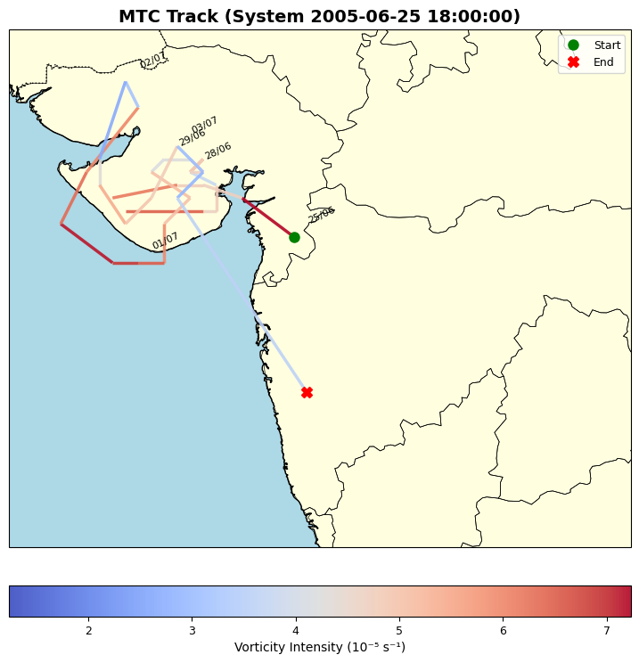

```python
import xarray as xr
import matplotlib.pyplot as plt
import cartopy.crs as ccrs
import cartopy.feature as cfeature
from matplotlib.collections import LineCollection
import numpy as np
from datetime import datetime, timedelta
import pandas as pd

# === Open NetCDF ===
ds = xr.open_dataset(
    "/home/pradeep/Desktop/AUTOMATIC_TRACKING_GUTHUB/DATA/MID_CYCLONE_TRACKS_JUN_SEP_1998-2019_600hPa.nc"
)
#print(ds)

# === Choose which cyclone/system to plot ===
system_index = 11198   # <-- change this number

# Extract track length
track_len = int(ds["TRACK_LENGTH"].values[system_index])

# Extract system variables
lats = ds["LAT_RECORD"].values[system_index, :track_len]
lons = ds["LON_RECORD"].values[system_index, :track_len]
intensity = ds["VOM_RECORD"].values[system_index, :track_len]
times = ds["TIME_RECORD"].values[system_index, :track_len]

# === Convert TIME_RECORD robustly ===
def convert_time(times):
    """Convert TIME_RECORD to datetime, handling both YYYYMMDDHH and hours-since-1900."""
    times = np.array(times)

    # Case 1: looks like YYYYMMDDHH
    if np.nanmin(times) > 1e9 and np.nanmax(times) < 1e11:
        return [datetime.strptime(str(int(t)), "%Y%m%d%H") for t in times if not np.isnan(t)]

    # Case 2: hours since 1900-01-01
    base_time = pd.Timestamp("1900-01-01 00:00:00")
    mask = np.isfinite(times) & (times > -1e6) & (times < 1e6*24)  # only keep reasonable values
    return pd.to_datetime(times[mask], unit="h", origin=base_time).to_pydatetime().tolist()

times = convert_time(times)

# === Prepare LineCollection ===
points = np.array([lons, lats]).T.reshape(-1, 1, 2)
segments = np.concatenate([points[:-1], points[1:]], axis=1)

lc = LineCollection(
    segments,
    cmap="coolwarm",
    norm=plt.Normalize(np.nanmin(intensity), np.nanmax(intensity))
)
lc.set_array(intensity[:-1])
lc.set_linewidth(2.5)
lc.set_alpha(0.9)

# === Plot Map (focused on India) ===
fig = plt.figure(figsize=(9, 11))
ax = plt.axes(projection=ccrs.PlateCarree())
ax.set_extent([68, 80, 15, 25], crs=ccrs.PlateCarree())  # India & neighborhood

ax.add_feature(cfeature.COASTLINE, linewidth=1)
ax.add_feature(cfeature.BORDERS, linestyle=":")
ax.add_feature(cfeature.LAND, facecolor="lightyellow")
ax.add_feature(cfeature.OCEAN, facecolor="lightblue")
ax.add_feature(cfeature.STATES.with_scale("50m"), linewidth=0.5)

ax.add_collection(lc)

# Start & End markers
ax.plot(lons[0], lats[0], "o", color="green", markersize=8,
        transform=ccrs.PlateCarree(), label="Start")
ax.plot(lons[-1], lats[-1], "X", color="red", markersize=8,
        transform=ccrs.PlateCarree(), label="End")

# Add date labels every ~5 points (if times available)
if len(times) > 0:
    for i in range(0, min(len(lats), len(times)), 5):
        try:
            date_label = times[i].strftime("%d/%m")
            ax.text(lons[i]+0.25, lats[i]+0.25, date_label,
                    fontsize=8, transform=ccrs.PlateCarree(),
                    rotation=25, color="black")
        except Exception:
            pass  # skip bad times

# Colorbar
cb = plt.colorbar(lc, ax=ax, orientation="horizontal", fraction=0.045, pad=0.05)
cb.set_label("Vorticity Intensity (10⁻⁵ s⁻¹)", fontsize=10)
cb.ax.tick_params(labelsize=9)

plt.title(f"MTC Track (System {times[0]})", fontsize=14, fontweight="bold")
plt.legend(loc="upper right", fontsize=9)
plt.savefig(f"../FIGURES/track_{system_index}.png", dpi=300, bbox_inches="tight")
plt.show()
```

**Example 2:** Track of a random low-pressure system (LPS) that formed in the Bay of Bengal and reached the Arabian Sea, precisely tracked by the tracking algorithm.

The accuracy of the method is demonstrated below for Cyclone Index = 27716. The tracking algorithm captured a track length of 51 six-hourly time steps, starting on 2016-08-13 18:00 UTC and ending on 2016-08-26 06:00 UTC, as recorded in the `TIME_RECORD` variable of the tracking algorithm output file.

The track has been plotted using `LAT_RECORD` and `LON_RECORD` as x-y coordinates, with `VOM_RECORD` representing the intensity of the cyclone, shown as the color of the track.

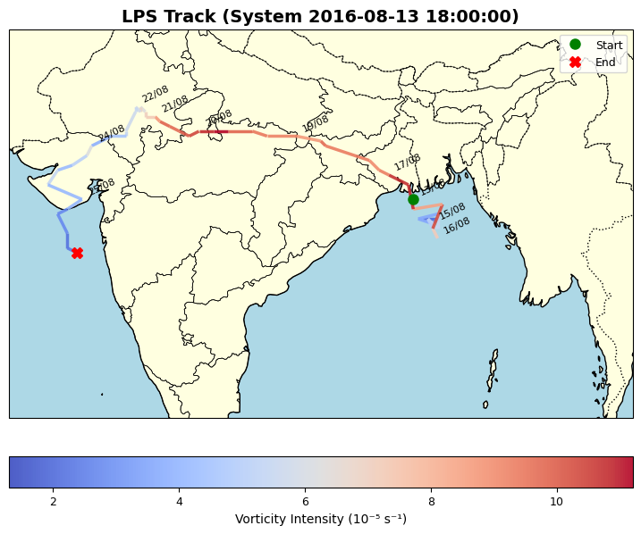

```python
import xarray as xr
import matplotlib.pyplot as plt
import cartopy.crs as ccrs
import cartopy.feature as cfeature
from matplotlib.collections import LineCollection
import numpy as np
from datetime import datetime, timedelta
import pandas as pd

# === Open NetCDF ===
ds = xr.open_dataset(
    "/home/pradeep/Desktop/AUTOMATIC_TRACKING_GUTHUB/DATA/MID_CYCLONE_TRACKS_JUN_SEP_1998-2019_600hPa.nc"
)
#print(ds)

# === Choose which cyclone/system to plot ===
system_index = 27716   # <-- change this number

# Extract track length
track_len = int(ds["TRACK_LENGTH"].values[system_index])

# Extract system variables
lats = ds["LAT_RECORD"].values[system_index, :track_len]
lons = ds["LON_RECORD"].values[system_index, :track_len]
intensity = ds["VOM_RECORD"].values[system_index, :track_len]
times = ds["TIME_RECORD"].values[system_index, :track_len]

# === Convert TIME_RECORD robustly ===
def convert_time(times):
    """Convert TIME_RECORD to datetime, handling both YYYYMMDDHH and hours-since-1900."""
    times = np.array(times)

    # Case 1: looks like YYYYMMDDHH
    if np.nanmin(times) > 1e9 and np.nanmax(times) < 1e11:
        return [datetime.strptime(str(int(t)), "%Y%m%d%H") for t in times if not np.isnan(t)]

    # Case 2: hours since 1900-01-01
    base_time = pd.Timestamp("1900-01-01 00:00:00")
    mask = np.isfinite(times) & (times > -1e6) & (times < 1e6*24)  # only keep reasonable values
    return pd.to_datetime(times[mask], unit="h", origin=base_time).to_pydatetime().tolist()

times = convert_time(times)

# === Prepare LineCollection ===
points = np.array([lons, lats]).T.reshape(-1, 1, 2)
segments = np.concatenate([points[:-1], points[1:]], axis=1)

lc = LineCollection(
    segments,
    cmap="coolwarm",
    norm=plt.Normalize(np.nanmin(intensity), np.nanmax(intensity))
)
lc.set_array(intensity[:-1])
lc.set_linewidth(2.5)
lc.set_alpha(0.9)

# === Plot Map (focused on India) ===
fig = plt.figure(figsize=(9, 11))
ax = plt.axes(projection=ccrs.PlateCarree())
ax.set_extent([68, 100, 10, 30], crs=ccrs.PlateCarree())  # India & neighborhood

ax.add_feature(cfeature.COASTLINE, linewidth=1)
ax.add_feature(cfeature.BORDERS, linestyle=":")
ax.add_feature(cfeature.LAND, facecolor="lightyellow")
ax.add_feature(cfeature.OCEAN, facecolor="lightblue")
ax.add_feature(cfeature.STATES.with_scale("50m"), linewidth=0.5)

ax.add_collection(lc)

# Start & End markers
ax.plot(lons[0], lats[0], "o", color="green", markersize=8,
        transform=ccrs.PlateCarree(), label="Start")
ax.plot(lons[-1], lats[-1], "X", color="red", markersize=8,
        transform=ccrs.PlateCarree(), label="End")

# Add date labels every ~5 points (if times available)
if len(times) > 0:
    for i in range(0, min(len(lats), len(times)), 5):
        try:
            date_label = times[i].strftime("%d/%m")
            ax.text(lons[i]+0.25, lats[i]+0.25, date_label,
                    fontsize=8, transform=ccrs.PlateCarree(),
                    rotation=25, color="black")
        except Exception:
            pass  # skip bad times

# Colorbar
cb = plt.colorbar(lc, ax=ax, orientation="horizontal", fraction=0.045, pad=0.05)
cb.set_label("Vorticity Intensity (10⁻⁵ s⁻¹)", fontsize=10)
cb.ax.tick_params(labelsize=9)

plt.title(f"LPS Track (System {times[0]})", fontsize=14, fontweight="bold")
plt.legend(loc="upper right", fontsize=9)
plt.savefig(f"../FIGURES/track_{system_index}.png", dpi=300, bbox_inches="tight")
plt.show()
```

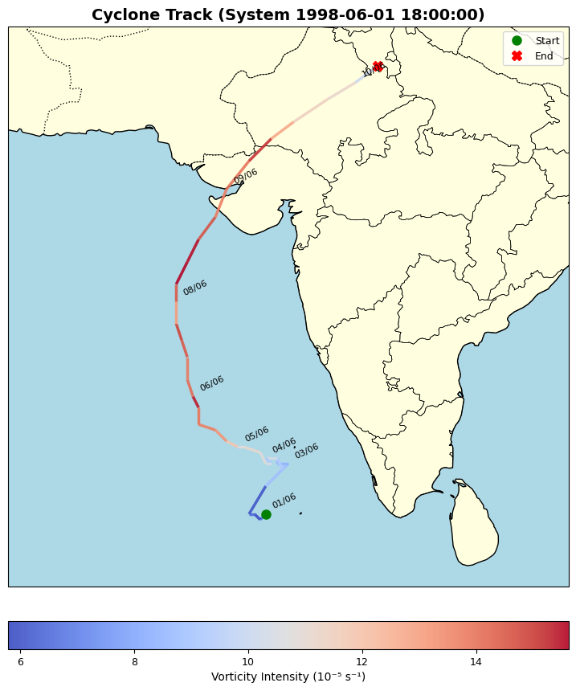

```python
import xarray as xr
import matplotlib.pyplot as plt
import cartopy.crs as ccrs
import cartopy.feature as cfeature
from matplotlib.collections import LineCollection
import numpy as np
from datetime import datetime, timedelta
import pandas as pd

# === Open NetCDF ===
ds = xr.open_dataset(
    "/home/pradeep/Desktop/AUTOMATIC_TRACKING_GUTHUB/DATA/MID_CYCLONE_TRACKS_JUN_SEP_1998-2019_600hPa.nc"
)
#print(ds)

# === Choose which cyclone/system to plot ===
system_index = 39   # <-- change this number

# Extract track length
track_len = int(ds["TRACK_LENGTH"].values[system_index])

# Extract system variables
lats = ds["LAT_RECORD"].values[system_index, :track_len]
lons = ds["LON_RECORD"].values[system_index, :track_len]
intensity = ds["VOM_RECORD"].values[system_index, :track_len]
times = ds["TIME_RECORD"].values[system_index, :track_len]

# === Convert TIME_RECORD robustly ===
def convert_time(times):
    """Convert TIME_RECORD to datetime, handling both YYYYMMDDHH and hours-since-1900."""
    times = np.array(times)

    # Case 1: looks like YYYYMMDDHH
    if np.nanmin(times) > 1e9 and np.nanmax(times) < 1e11:
        return [datetime.strptime(str(int(t)), "%Y%m%d%H") for t in times if not np.isnan(t)]

    # Case 2: hours since 1900-01-01
    base_time = pd.Timestamp("1900-01-01 00:00:00")
    mask = np.isfinite(times) & (times > -1e6) & (times < 1e6*24)  # only keep reasonable values
    return pd.to_datetime(times[mask], unit="h", origin=base_time).to_pydatetime().tolist()

times = convert_time(times)

# === Prepare LineCollection ===
points = np.array([lons, lats]).T.reshape(-1, 1, 2)
segments = np.concatenate([points[:-1], points[1:]], axis=1)

lc = LineCollection(
    segments,
    cmap="coolwarm",
    norm=plt.Normalize(np.nanmin(intensity), np.nanmax(intensity))
)
lc.set_array(intensity[:-1])
lc.set_linewidth(2.5)
lc.set_alpha(0.9)

# === Plot Map (focused on India) ===
fig = plt.figure(figsize=(9, 11))
ax = plt.axes(projection=ccrs.PlateCarree())
ax.set_extent([60, 85, 5, 30], crs=ccrs.PlateCarree())  # India & neighborhood

ax.add_feature(cfeature.COASTLINE, linewidth=1)
ax.add_feature(cfeature.BORDERS, linestyle=":")
ax.add_feature(cfeature.LAND, facecolor="lightyellow")
ax.add_feature(cfeature.OCEAN, facecolor="lightblue")
ax.add_feature(cfeature.STATES.with_scale("50m"), linewidth=0.5)

ax.add_collection(lc)

# Start & End markers
ax.plot(lons[0], lats[0], "o", color="green", markersize=8,
        transform=ccrs.PlateCarree(), label="Start")
ax.plot(lons[-1], lats[-1], "X", color="red", markersize=8,
        transform=ccrs.PlateCarree(), label="End")

# Add date labels every ~5 points (if times available)
if len(times) > 0:
    for i in range(0, min(len(lats), len(times)), 5):
        try:
            date_label = times[i].strftime("%d/%m")
            ax.text(lons[i]+0.25, lats[i]+0.25, date_label,
                    fontsize=8, transform=ccrs.PlateCarree(),
                    rotation=25, color="black")
        except Exception:
            pass  # skip bad times

# Colorbar
cb = plt.colorbar(lc, ax=ax, orientation="horizontal", fraction=0.045, pad=0.05)
cb.set_label("Vorticity Intensity (10⁻⁵ s⁻¹)", fontsize=10)
cb.ax.tick_params(labelsize=9)

plt.title(f"Cyclone Track (System {times[0]})", fontsize=14, fontweight="bold")
plt.legend(loc="upper right", fontsize=9)
plt.savefig(f"../FIGURES/track_{system_index}.png", dpi=300, bbox_inches="tight")
plt.show()
```

### Cyclone Track Density Analysis with Stationary Cyclone Filtering

This Python script calculates and visualizes **unique-system cyclone density** from ERA5-derived mid-tropospheric (600 hPa) cyclone tracks. Key steps and logic are as follows:

1. **User Parameters**
   - `GRID_SIZE`, `LAT_RANGE`, `LON_RANGE`: Define the spatial resolution and extent for the density grid.
   - `GENESIS_LAT_MAX`, `TRACK_LEN_MIN`, `SPEED_MIN_MS`, `Q_RECORD_MIN`: Filter cyclones by genesis latitude, minimum track length, mean speed, and mid-level humidity.
   - `SPEED_STATIONARY_THRESHOLD`, `MIN_STATIONARY_POINTS`: Cyclones that remain nearly stationary for a minimum number of consecutive steps are excluded.
   - `DENSITY_MODE`: Option to compute mean density per year or total density over all years.
2. **Data Loading**
   - The script reads a NetCDF file containing cyclone tracks at 600 hPa, extracting latitude, longitude, track length, and humidity (`Q_RECORD`).
3. **Cyclone Filtering**
   - Tracks shorter than `TRACK_LEN_MIN` or with genesis beyond `GENESIS_LAT_MAX` are discarded.
   - Mean speed is computed using stepwise distances between consecutive track points. Tracks with mean speed below `SPEED_MIN_MS` or maximum Q below `Q_RECORD_MIN` are filtered out.
   - **Stationary cyclone check:** Tracks with consecutive points moving slower than `SPEED_STATIONARY_THRESHOLD` for at least `MIN_STATIONARY_POINTS` are removed.
4. **Density Grid Calculation**
   - The domain is divided into latitude-longitude bins, and unique cyclone visits per grid cell are counted.
   - If `DENSITY_MODE="mean"`, the count is normalized by the number of years (`N_YEARS`).
5. **Visualization**
   - The density field is plotted using **Cartopy** with coastlines, borders, land, and ocean.
   - A color map (`Reds`) represents the unique-system density.
   - The resulting figure highlights regions with frequent cyclone activity while excluding stationary or weak systems.
6. **Output**
   - A high-resolution PNG file is saved for publication-quality figures.

```
Counted 1565 systems after stationary cyclone filtering.
```

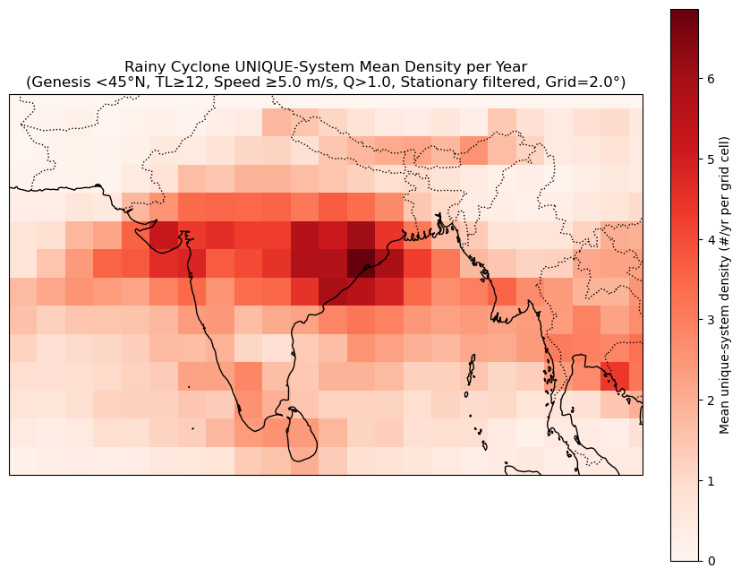

```python
import numpy as np
import xarray as xr
import matplotlib.pyplot as plt
import cartopy.crs as ccrs
import cartopy.feature as cfeature

# ============================================================
# USER-CONTROL PARAMETERS
# ============================================================
GRID_SIZE = 2.0         # degrees
LAT_RANGE = (5, 32)
LON_RANGE = (60, 105)

GENESIS_LAT_MAX = 45
TRACK_LEN_MIN   = 12
SPEED_MIN_MS    = 5.0
Q_RECORD_MIN    = 1.0

# Stationary cyclone filter
SPEED_STATIONARY_THRESHOLD = 1   # m/s
MIN_STATIONARY_POINTS      = 2           # minimum consecutive points below threshold

DENSITY_MODE = "mean"
DATA_FILE    = "/home/pradeep/Desktop/AUTOMATIC_TRACKING_GUTHUB/DATA/MID_CYCLONE_TRACKS_JUN_SEP_1998-2019_600hPa.nc"
N_YEARS      = 2019 - 1998 + 1

# ============================================================
# Load dataset
# ============================================================
ds = xr.open_dataset(DATA_FILE)

def haversine(lat1, lon1, lat2, lon2):
    R=6371.0
    lat1,lon1,lat2,lon2 = map(np.radians,[lat1,lon1,lat2,lon2])
    dlat=lat2-lat1; dlon=lon2-lon1
    a=np.sin(dlat/2)**2+np.cos(lat1)*np.cos(lat2)*np.sin(dlon/2)**2
    return R*2*np.arcsin(np.sqrt(a))

# Extract
track_lengths = ds["TRACK_LENGTH"].values
lat_rec       = ds["LAT_RECORD"].values
lon_rec       = ds["LON_RECORD"].values
q_rec         = ds["Q_RECORD"].values

# Define grid
lat_bins = np.arange(LAT_RANGE[0], LAT_RANGE[1]+GRID_SIZE, GRID_SIZE)
lon_bins = np.arange(LON_RANGE[0], LON_RANGE[1]+GRID_SIZE, GRID_SIZE)
H_unique = np.zeros((lat_bins.size-1, lon_bins.size-1), dtype=int)

valid_ids = []

dt = 6*3600  # seconds (6h timestep)

for i in range(track_lengths.shape[0]):
    tl = int(track_lengths[i])
    if tl < TRACK_LEN_MIN:
        continue

    lats = lat_rec[i,:tl]; lons = lon_rec[i,:tl]
    if not (np.isfinite(lats[0]) and np.isfinite(lons[0])):
        continue
    if lats[0] >= GENESIS_LAT_MAX:
        continue

    # compute stepwise speed
    dy = np.diff(lats)*111e3
    dx = np.diff(lons)*111e3*np.cos(np.radians((lats[:-1]+lats[1:])/2))
    speed = np.sqrt(dx**2 + dy**2)/dt

    # filter mean speed
    mean_speed_ms = np.nanmean(speed)
    if mean_speed_ms < SPEED_MIN_MS:
        continue

    if np.nanmax(q_rec[i,:tl]) <= Q_RECORD_MIN:
        continue

    # filter stationary cyclones
    stationary = speed < SPEED_STATIONARY_THRESHOLD
    # check for consecutive stationary points
    count = 0
    stationary_flag = False
    for s in stationary:
        if s:
            count += 1
            if count >= MIN_STATIONARY_POINTS:
                stationary_flag = True
                break
        else:
            count = 0
    if stationary_flag:
        continue

    # unique visit
    li = np.digitize(lats, lat_bins)-1
    lj = np.digitize(lons, lon_bins)-1
    mask = (li>=0)&(li<H_unique.shape[0])&(lj>=0)&(lj<H_unique.shape[1])
    visited = set(zip(li[mask], lj[mask]))
    for (ii,jj) in visited:
        H_unique[ii,jj] += 1

    valid_ids.append(i)

print(f"Counted {len(valid_ids)} systems after stationary cyclone filtering.")

# ============================================================
# Density Mode
# ============================================================
if DENSITY_MODE.lower() == "mean":
    H_plot = H_unique / N_YEARS
    cbar_label = "Mean unique-system density (#/yr per grid cell)"
    title_mode = "Mean Density per Year"
else:
    H_plot = H_unique
    cbar_label = "Unique-system density (total # per grid cell)"
    title_mode = "Total Density (1998–2019)"

# ============================================================
# Plot
# ============================================================
fig = plt.figure(figsize=(10,8))
ax = plt.axes(projection=ccrs.PlateCarree())
ax.set_extent([LON_RANGE[0], LON_RANGE[1], LAT_RANGE[0], LAT_RANGE[1]], crs=ccrs.PlateCarree())
ax.add_feature(cfeature.COASTLINE, linewidth=1)
ax.add_feature(cfeature.BORDERS, linestyle=":")
ax.add_feature(cfeature.LAND, facecolor="lightyellow")
ax.add_feature(cfeature.OCEAN, facecolor="lightblue")

LON, LAT = np.meshgrid(lon_bins, lat_bins)
m = ax.pcolormesh(LON, LAT, H_plot, cmap="Reds", shading="auto")
cb = plt.colorbar(m, ax=ax, fraction=0.046, pad=0.04)
cb.set_label(cbar_label)
plt.title(f"Rainy Cyclone UNIQUE-System {title_mode}\n"
          f"(Genesis <{GENESIS_LAT_MAX}°N, TL≥{TRACK_LEN_MIN}, Speed ≥{SPEED_MIN_MS} m/s, "
          f"Q>{Q_RECORD_MIN}, Stationary filtered, Grid={GRID_SIZE}°)")
plt.savefig("../FIGURES/track_density_unique_stationary_filtered.png", dpi=300, bbox_inches="tight")
plt.show()
```